# Biostat 203B Homework 2 Online Server

Due Feb 6 @ 11:59PM

YANLONG BAI

```r
knitr::opts_chunk$set(echo = TRUE, cache = TRUE, cache.lazy = FALSE)
library(R.utils)
library(tidyverse)
library(data.table)
library(lubridate)
library(dummies)
```

```r
os <- sessionInfo()$running
if (str_detect(os, "Linux")) {
  mimic_path <- "/mnt/mimiciv/1.0"
} else if (str_detect(os, "macOS")) {
  mimic_path <- "/Users/huazhou/Documents/Box Sync/MIMIC/mimic-iv-1.0"
}
```

In this exercise, we use tidyverse (ggpot2, dplyr, etc) to explore the [MIMIC-IV](https://mimic.mit.edu/docs/iv/) data introduced in [homework 1](https://ucla-biostat-203b.github.io/2022winter/hw/hw1/hw1.html) and to build a cohort of ICU stays.

```r
# tree -s -L 2 /Users/huazhou/Documents/Box\ Sync/MIMIC/mimic-iv-1.0
system(str_c("tree -s -L 2 ", shQuote(mimic_path)), intern = TRUE)
```

```
##  [1] "/mnt/mimiciv/1.0"
##  [2] "├── [       4096]  core"
##  [3] "│   ├── [   17208966]  admissions.csv.gz"
##  [4] "│   ├── [        606]  index.html"
##  [5] "│   ├── [    2955582]  patients.csv.gz"
##  [6] "│   └── [   53014503]  transfers.csv.gz"
##  [7] "├── [       4096]  hosp"
##  [8] "│   ├── [     430049]  d_hcpcs.csv.gz"
##  [9] "│   ├── [   29531152]  diagnoses_icd.csv.gz"
## [10] "│   ├── [     863239]  d_icd_diagnoses.csv.gz"
## [11] "│   ├── [     579998]  d_icd_procedures.csv.gz"
## [12] "│   ├── [      14898]  d_labitems.csv.gz"
## [13] "│   ├── [   11684062]  drgcodes.csv.gz"
## [14] "│   ├── [  515763427]  emar.csv.gz"
## [15] "│   ├── [  476252563]  emar_detail.csv.gz"
```

[output cut: 26 more lines]

## Q1. `read.csv` (base R) vs `read_csv` (tidyverse) vs `fread` (data.table)

There are quite a few utilities in R for reading plain text data files. Let us test the speed of reading a moderate sized compressed csv file, `admissions.csv.gz`, by three programs: `read.csv` in base R, `read_csv` in tidyverse, and `fread` in the popular data.table package.

Which function is fastest? Is there difference in the (default) parsed data types? (Hint: R function `system.time` measures run times.)

**Solution**

```r
system.time(read.csv("/mnt/mimiciv/1.0/core/admissions.csv.gz"))
```

```
##    user  system elapsed
##  40.562   0.281  40.853
```

```r
system.time(read_csv("/mnt/mimiciv/1.0/core/admissions.csv.gz", show_col_types = FALSE))
```

```
##    user  system elapsed
##   3.400   0.188   1.850
```

```r
system.time(fread("/mnt/mimiciv/1.0/core/admissions.csv.gz"))
```

```
##    user  system elapsed
##   1.661   0.085   0.889
```

For later questions, we stick to the tidyverse.

## Q2. ICU stays

`icustays.csv.gz` (https://mimic.mit.edu/docs/iv/modules/icu/icustays/) contains data about Intensive Care Units (ICU) stays. The first 10 lines are

```r
system(
  str_c(
    "zcat < ",
    shQuote(str_c(mimic_path, "/icu/icustays.csv.gz")),
    " | head"
    ),
  intern = TRUE
)
```

```
##  [1] "subject_id,hadm_id,stay_id,first_careunit,last_careunit,intime,outtime,los"
##  [2] "17867402,24528534,31793211,Trauma SICU (TSICU),Trauma SICU (TSICU),2154-03-03 04:11:00,2154-03-04 18:16:56,1.5874537037037035"
##  [3] "14435996,28960964,31983544,Trauma SICU (TSICU),Trauma SICU (TSICU),2150-06-19 17:57:00,2150-06-22 18:33:54,3.025625"
##  [4] "17609946,27385897,33183475,Trauma SICU (TSICU),Trauma SICU (TSICU),2138-02-05 18:54:00,2138-02-15 12:42:05,9.741724537037038"
##  [5] "18966770,23483021,34131444,Trauma SICU (TSICU),Trauma SICU (TSICU),2123-10-25 10:35:00,2123-10-25 18:59:47,0.35054398148148147"
##  [6] "12776735,20817525,34547665,Neuro Stepdown,Neuro Stepdown,2200-07-12 00:33:00,2200-07-13 16:44:40,1.6747685185185184"
##  [7] "10215159,24283593,34569476,Trauma SICU (TSICU),Trauma SICU (TSICU),2124-09-20 15:05:29,2124-09-21 22:06:58,1.2926967592592593"
##  [8] "14489052,26516390,35056286,Trauma SICU (TSICU),Trauma SICU (TSICU),2118-10-26 10:33:56,2118-10-26 20:28:10,0.4126620370370371"
##  [9] "15914763,28906020,36909804,Trauma SICU (TSICU),Trauma SICU (TSICU),2176-12-14 12:00:00,2176-12-17 11:47:01,2.9909837962962964"
## [10] "16256226,20013290,39289362,Neuro Stepdown,Neuro Stepdown,2150-12-20 16:09:08,2150-12-21 14:58:40,0.9510648148148149"
```

1. Import `icustatys.csv.gz` as a tibble `icustays_tble`.

**Solution**

```r
icustays_tble = read_csv("/mnt/mimiciv/1.0/icu/icustays.csv.gz", show_col_types = FALSE)
icustays_tble
```

```
## # A tibble: 76,540 × 8
##    subject_id  hadm_id  stay_id first_careunit last_careunit intime
##         <dbl>    <dbl>    <dbl> <chr>          <chr>         <dttm>
##  1   17867402 24528534 31793211 Trauma SICU (… Trauma SICU … 2154-03-03 04:11:00
##  2   14435996 28960964 31983544 Trauma SICU (… Trauma SICU … 2150-06-19 17:57:00
##  3   17609946 27385897 33183475 Trauma SICU (… Trauma SICU … 2138-02-05 18:54:00
##  4   18966770 23483021 34131444 Trauma SICU (… Trauma SICU … 2123-10-25 10:35:00
##  5   12776735 20817525 34547665 Neuro Stepdown Neuro Stepdo… 2200-07-12 00:33:00
##  6   10215159 24283593 34569476 Trauma SICU (… Trauma SICU … 2124-09-20 15:05:29
##  7   14489052 26516390 35056286 Trauma SICU (… Trauma SICU … 2118-10-26 10:33:56
##  8   15914763 28906020 36909804 Trauma SICU (… Trauma SICU … 2176-12-14 12:00:00
##  9   16256226 20013290 39289362 Neuro Stepdown Neuro Stepdo… 2150-12-20 16:09:08
## 10   19194449 21641999 39387567 Coronary Care… Coronary Car… 2123-11-12 02:53:35
## # … with 76,530 more rows, and 2 more variables: outtime <dttm>, los <dbl>
```

2. How many unique `subject_id`? Can a `subject_id` have multiple ICU stays?

**Solution**

```r
distinct(icustays_tble, subject_id, .keep_all = TRUE) %>%
  summarise(n = n())
```

```
## # A tibble: 1 × 1
##       n
##   <int>
## 1 53150
```

The result indicates that there are only 53150 unique `subject_id`s, which is much less than the total number (76540). So there must be some `subject_id`s having multiple ICU stays.

3. For each `subject_id`, let’s only keep the first ICU stay in the tibble `icustays_tble`.

**Solution**

```r
icustays_tble = icustays_tble %>%
  group_by(subject_id) %>%
  arrange(intime, .by_group = TRUE) %>%
  slice_head(n = 1) %>%
  ungroup()
icustays_tble
```

```
## # A tibble: 53,150 × 8
##    subject_id  hadm_id  stay_id first_careunit last_careunit intime
##         <dbl>    <dbl>    <dbl> <chr>          <chr>         <dttm>
##  1   10000032 29079034 39553978 Medical Inten… Medical Inte… 2180-07-23 14:00:00
##  2   10000980 26913865 39765666 Medical Inten… Medical Inte… 2189-06-27 08:42:00
##  3   10001217 24597018 37067082 Surgical Inte… Surgical Int… 2157-11-20 19:18:02
##  4   10001725 25563031 31205490 Medical/Surgi… Medical/Surg… 2110-04-11 15:52:22
##  5   10001884 26184834 37510196 Medical Inten… Medical Inte… 2131-01-11 04:20:05
##  6   10002013 23581541 39060235 Cardiac Vascu… Cardiac Vasc… 2160-05-18 10:00:53
##  7   10002155 23822395 33685454 Coronary Care… Coronary Car… 2129-08-04 12:45:00
##  8   10002223 22494570 39638202 Trauma SICU (… Trauma SICU … 2158-01-15 08:01:49
##  9   10002348 22725460 32610785 Neuro Interme… Neuro Interm… 2112-11-30 23:24:00
## 10   10002428 28662225 33987268 Medical Inten… Medical Inte… 2156-04-12 16:24:18
## # … with 53,140 more rows, and 2 more variables: outtime <dttm>, los <dbl>
```

## Q3. `admission` data

Information of the patients admitted into hospital is available in `admissions.csv.gz`. See https://mimic.mit.edu/docs/iv/modules/core/admissions/ for details of each field in this file. The first 10 lines are

```r
system(
  str_c(
    "zcat < ",
    shQuote(str_c(mimic_path, "/core/admissions.csv.gz")),
    " | head"
    ),
  intern = TRUE
)
```

```
##  [1] "subject_id,hadm_id,admittime,dischtime,deathtime,admission_type,admission_location,discharge_location,insurance,language,marital_status,ethnicity,edregtime,edouttime,hospital_expire_flag"
##  [2] "14679932,21038362,2139-09-26 14:16:00,2139-09-28 11:30:00,,ELECTIVE,,HOME,Other,ENGLISH,SINGLE,UNKNOWN,,,0"
##  [3] "15585972,24941086,2123-10-07 23:56:00,2123-10-12 11:22:00,,ELECTIVE,,HOME,Other,ENGLISH,,WHITE,,,0"
##  [4] "11989120,21965160,2147-01-14 09:00:00,2147-01-17 14:25:00,,ELECTIVE,,HOME,Other,ENGLISH,,UNKNOWN,,,0"
##  [5] "17817079,24709883,2165-12-27 17:33:00,2165-12-31 21:18:00,,ELECTIVE,,HOME,Other,ENGLISH,,OTHER,,,0"
##  [6] "15078341,23272159,2122-08-28 08:48:00,2122-08-30 12:32:00,,ELECTIVE,,HOME,Other,ENGLISH,,BLACK/AFRICAN AMERICAN,,,0"
##  [7] "19124609,20517215,2169-03-14 12:44:00,2169-03-20 19:15:00,,ELECTIVE,,HOME,Other,ENGLISH,,UNKNOWN,,,0"
##  [8] "17301855,29732723,2140-06-06 14:23:00,2140-06-08 14:25:00,,ELECTIVE,,HOME,Other,ENGLISH,,WHITE,,,0"
##  [9] "17991012,24298836,2181-07-10 20:28:00,2181-07-12 15:49:00,,ELECTIVE,,HOME,Other,ENGLISH,,WHITE,,,0"
## [10] "16865435,23216961,2185-07-19 02:12:00,2185-07-21 11:50:00,,ELECTIVE,,HOME,Other,ENGLISH,,WHITE,,,0"
```

1. Import `admissions.csv.gz` as a tibble `admissions_tble`.

**Solution**

```r
admissions_tble = read_csv("/mnt/mimiciv/1.0/core/admissions.csv.gz", show_col_types = FALSE)
admissions_tble
```

```
## # A tibble: 523,740 × 15
##    subject_id  hadm_id admittime           dischtime
##         <dbl>    <dbl> <dttm>              <dttm>
##  1   14679932 21038362 2139-09-26 14:16:00 2139-09-28 11:30:00
##  2   15585972 24941086 2123-10-07 23:56:00 2123-10-12 11:22:00
##  3   11989120 21965160 2147-01-14 09:00:00 2147-01-17 14:25:00
##  4   17817079 24709883 2165-12-27 17:33:00 2165-12-31 21:18:00
##  5   15078341 23272159 2122-08-28 08:48:00 2122-08-30 12:32:00
##  6   19124609 20517215 2169-03-14 12:44:00 2169-03-20 19:15:00
##  7   17301855 29732723 2140-06-06 14:23:00 2140-06-08 14:25:00
##  8   17991012 24298836 2181-07-10 20:28:00 2181-07-12 15:49:00
##  9   16865435 23216961 2185-07-19 02:12:00 2185-07-21 11:50:00
## 10   13693648 21640725 2111-01-30 23:43:00 2111-02-02 13:03:00
## # … with 523,730 more rows, and 11 more variables: deathtime <dttm>,
## #   admission_type <chr>, admission_location <chr>, discharge_location <chr>,
## #   insurance <chr>, language <chr>, marital_status <chr>, ethnicity <chr>,
## #   edregtime <dttm>, edouttime <dttm>, hospital_expire_flag <dbl>
```

2. Let’s only keep the admissions that have a match in `icustays_tble` according to `subject_id` and `hadmi_id`.

**Solution**

```r
# This is a cycle written by my own for this question, it also works but costs much more time, so I choose to use methods from dplyr.
testtib = admissions_tble[0,]
i = 1
j = 1
admissions_tble = arrange(admissions_tble, subject_id, hadm_id)
icustays_tble = arrange(icustays_tble, subject_id, hadm_id)
while (i < 523741) {
  while (j < 76541) {
    if(icustays_tble[j,1] == admissions_tble[i,1]){
      if(icustays_tble[j,2] == admissions_tble[i,2]){
        testtib = add_row(testtib, admissions_tble[i,])
        j = j + 1
        break
      }else if(icustays_tble[j,2] < admissions_tble[i,2]){
        j = j + 1
      }else {
        break
      }
    }else if(icustays_tble[j,1] < admissions_tble[i,1]){
      j = j + 1
    }else{
      break
    }
  }
  i = i + 1
}
admissions_tble = testtib
admissions_tble
```

```r
admissions_tble = admissions_tble %>%
  inner_join(select(icustays_tble, subject_id, hadm_id), by = c("subject_id", "hadm_id"))
admissions_tble
```

```
## # A tibble: 53,150 × 15
##    subject_id  hadm_id admittime           dischtime
##         <dbl>    <dbl> <dttm>              <dttm>
##  1   10222255 28200985 2120-11-20 20:25:00 2120-11-22 13:00:00
##  2   14485852 28712010 2113-10-31 00:23:00 2113-11-04 16:50:00
##  3   18709254 23758948 2195-10-12 01:31:00 2195-10-12 13:51:00
##  4   16837807 23526268 2151-03-19 06:09:00 2151-03-19 07:20:00
##  5   17642680 27734285 2116-05-29 12:48:00 2116-05-30 12:31:00
##  6   18230965 21251728 2142-03-12 20:00:00 2142-03-17 15:26:00
##  7   17374121 27667114 2115-07-22 07:15:00 2115-07-24 17:50:00
##  8   13346506 28533404 2181-11-19 14:32:00 2181-11-22 18:47:00
##  9   18030332 24679656 2152-07-22 21:28:00 2152-07-27 16:49:00
## 10   14328744 29576470 2126-08-20 09:26:00 2126-08-21 11:36:00
## # … with 53,140 more rows, and 11 more variables: deathtime <dttm>,
## #   admission_type <chr>, admission_location <chr>, discharge_location <chr>,
## #   insurance <chr>, language <chr>, marital_status <chr>, ethnicity <chr>,
## #   edregtime <dttm>, edouttime <dttm>, hospital_expire_flag <dbl>
```

3. Summarize the following variables by graphics.
- admission year
- admission month
- admission month day
- admission week day
- admission hour (anything unusual?)

**Solution**

RMK: for the following images, I use the `admissions_tble` instead of the `admissions_tble_filtered`, so if the images have little difference with your answer, this is the reason!!!

For “admission year”:

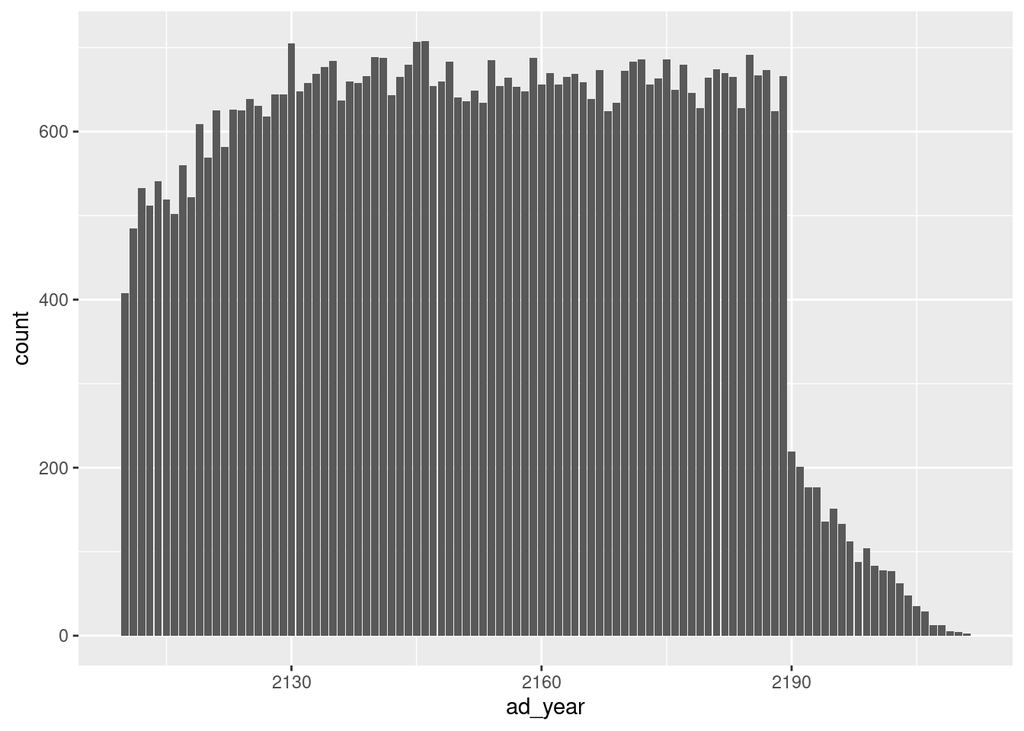

```r
ad_year = as.character(admissions_tble[[3]]) %>%
  substring(1, 4) %>%
  as.numeric()
y = as.data.frame(ad_year)
ggplot(data = y) +
  geom_bar(mapping = aes(x = ad_year))
```

```r
remove(y)
```

For “admission month”:

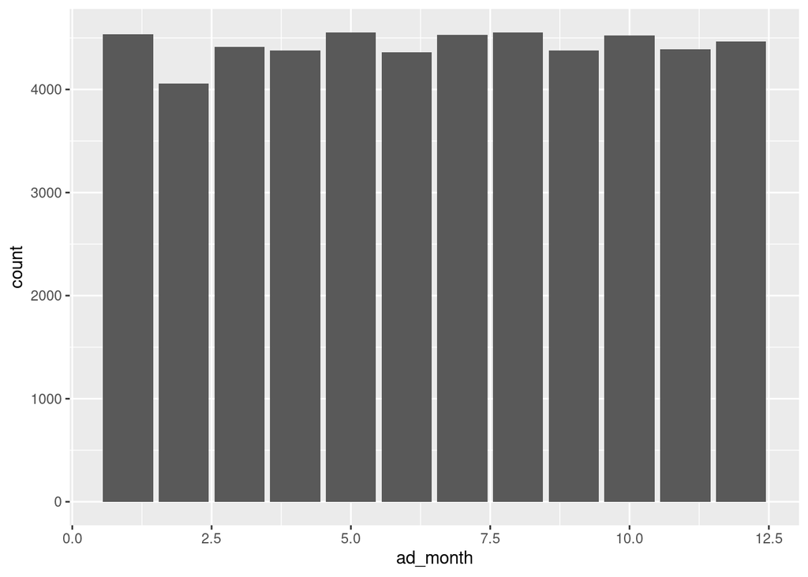

```r
ad_month = as.character(admissions_tble[[3]]) %>%
  substring(6, 7) %>%
  as.numeric()
m = as.data.frame(ad_month)
ggplot(data = m) +
  geom_bar(mapping = aes(x = ad_month))
```

```r
remove(m)
```

For “admission month day”:

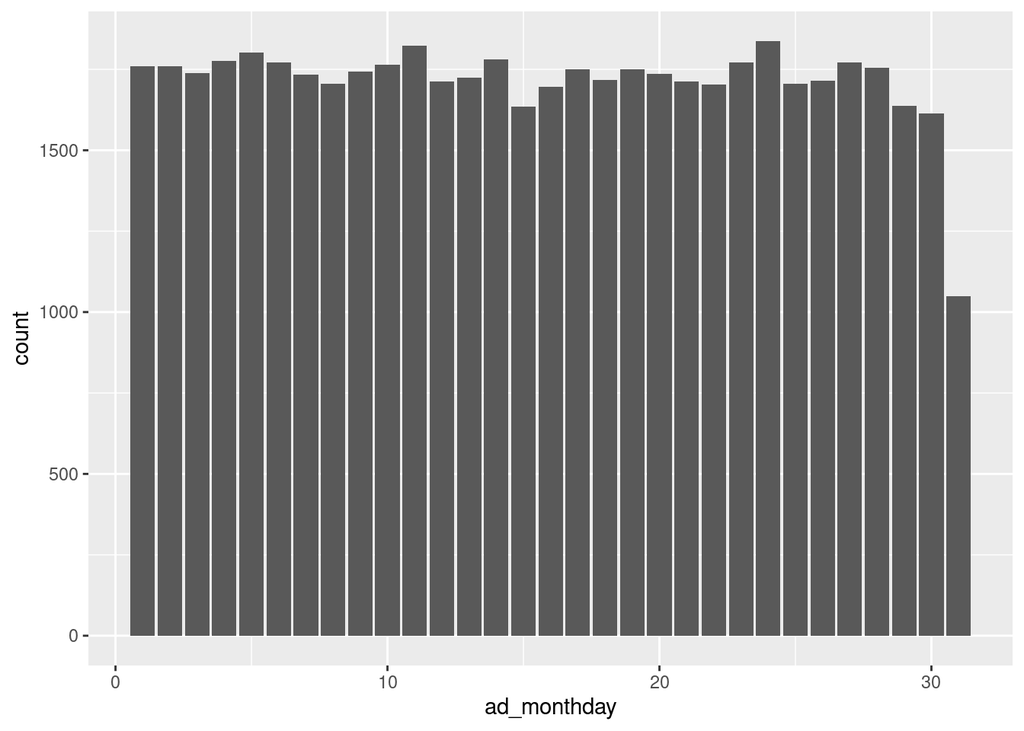

```r
ad_monthday = as.character(admissions_tble[[3]]) %>%
  substring(9, 10) %>%
  as.numeric()
md = as.data.frame(ad_monthday)
ggplot(data = md) +
  geom_bar(mapping = aes(x = ad_monthday))
```

```r
remove(md)
```

For “admission week day” (RMK: “0” represents Sunday):

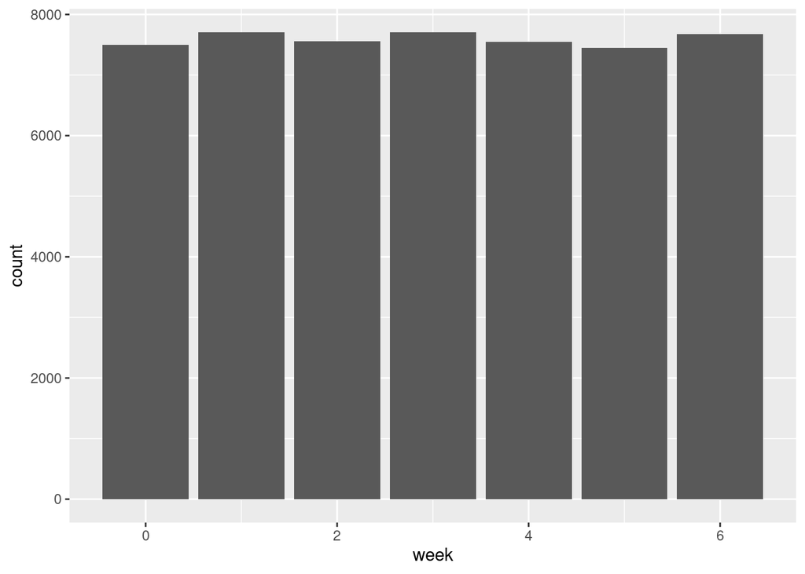

```r
weekday = NULL
c = 0
y = 0
week = 0
i = 1
year = 0
month = 0
ad_weekday = as.data.frame(weekday, matrix(nrow = 0, ncol = 1, dimnames = list(NULL, "weekday")))
#Zeller's congruence (the following code is written by myself)
while (i < 53151) {
  year = ad_year[i]
  month = ad_month[i]
  if(ad_month[i] == 1 || ad_month[i] == 2){
  year = ad_year[i] - 1
  month = ad_month[i] + 12
  }
  c = year %/% 100
  y = year - c * 100
  week = y + y %/% 4 + c %/% 4 - 2 * c + (26 * (month + 1)) %/% 10 + ad_monthday[i] - 1
  while (week < 0) {
    week = week + 7
  }
  week = week %% 7
  ad_weekday = rbind(ad_weekday, as.data.frame(week))
  i = i + 1
}
ggplot(data = ad_weekday) +
  geom_bar(mapping = aes(x = week))
```

```r
remove(c, i, month, week, weekday, y, year, ad_weekday, ad_month, ad_monthday, ad_year)
```

For “admission hour”:

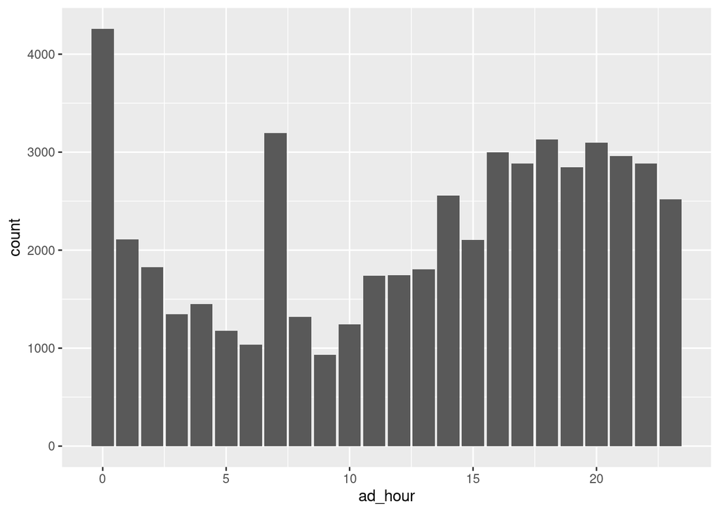

```r
ad_hour = as.character(admissions_tble[[3]]) %>%
  substring(12, 13) %>%
  as.numeric()
hr = as.data.frame(ad_hour)
ggplot(data = hr) +
  geom_bar(mapping = aes(x = ad_hour))
```

```r
remove(ad_hour, hr)
```

## Q4. `patients` data

Patient information is available in `patients.csv.gz`. See https://mimic.mit.edu/docs/iv/modules/core/patients/ for details of each field in this file. The first 10 lines are

```r
system(
  str_c(
    "zcat < ",
    shQuote(str_c(mimic_path, "/core/patients.csv.gz")),
    " | head"
    ),
  intern = TRUE
)
```

```
##  [1] "subject_id,gender,anchor_age,anchor_year,anchor_year_group,dod"
##  [2] "10000048,F,23,2126,2008 - 2010,"
##  [3] "10002723,F,0,2128,2017 - 2019,"
##  [4] "10003939,M,0,2184,2008 - 2010,"
##  [5] "10004222,M,0,2161,2014 - 2016,"
##  [6] "10005325,F,0,2154,2011 - 2013,"
##  [7] "10007338,F,0,2153,2017 - 2019,"
##  [8] "10008101,M,0,2142,2008 - 2010,"
##  [9] "10009872,F,0,2168,2014 - 2016,"
## [10] "10011333,F,0,2132,2014 - 2016,"
```

1. Import `patients.csv.gz` (https://mimic.mit.edu/docs/iv/modules/core/patients/) as a tibble `patients_tble` and only keep the patients who have a match in `icustays_tble` (according to `subject_id`).

**Solution**

```r
#This is a cycle written by my own for this question, it also works but costs much more time, so I choose to use methods from dplyr.
patients_tble = read_csv("/mnt/mimiciv/1.0/core/patients.csv.gz")
testtib = patients_tble[0,]
i = 1
j = 1
patients_tble = arrange(patients_tble, subject_id)
icustays_tble = arrange(icustays_tble, subject_id)
while (i < 382279) {
  while (j < 53151) {
    if(icustays_tble[j,1] == patients_tble[i,1]){
        testtib = add_row(testtib, patients_tble[i,])
        break
    }else if(icustays_tble[j,1] < patients_tble[i,1]){
      j = j + 1
    }else{
      break
    }
  }
  i = i + 1
}
patients_tble = testtib
patients_tble
```

```r
patients_tble = read_csv("/mnt/mimiciv/1.0/core/patients.csv.gz") %>%
  inner_join(select(icustays_tble, subject_id), by = "subject_id")
patients_tble
```

```
## # A tibble: 53,150 × 6
##    subject_id gender anchor_age anchor_year anchor_year_group dod
##         <dbl> <chr>       <dbl>       <dbl> <chr>             <date>
##  1   10018928 F              31        2125 2008 - 2010       NA
##  2   10076543 F              78        2187 2008 - 2010       NA
##  3   10098428 F              85        2119 2008 - 2010       NA
##  4   10127185 M              60        2141 2008 - 2010       NA
##  5   10148710 M              67        2137 2008 - 2010       NA
##  6   10156486 F              75        2124 2017 - 2019       NA
##  7   10159585 M              59        2146 2008 - 2010       2154-04-16
##  8   10171525 F              27        2115 2014 - 2016       NA
##  9   10196360 M              57        2118 2011 - 2013       NA
## 10   10227823 M              45        2156 2014 - 2016       NA
## # … with 53,140 more rows
```

2. Summarize variables `gender` and `anchor_age`, and explain any patterns you see.

**Solution**

```r
summary(as.factor(patients_tble[[2]]))# the total number of observations of two sexes.
```

```
##     F     M
## 23353 29797
```

```r
summary(patients_tble[[3]])# the overall summary statistics of "anchor_age".
```

```
##    Min. 1st Qu.  Median    Mean 3rd Qu.    Max.
##   18.00   53.00   65.00   63.51   77.00   91.00
```

```r
patients_tble %>%
group_by(gender) %>%
  summarise(mean(anchor_age, na.rm = TRUE))# the mean value of "anchor_age" of each gender.
```

```
## # A tibble: 2 × 2
##   gender `mean(anchor_age, na.rm = TRUE)`
##   <chr>                             <dbl>
## 1 F                                  64.8
## 2 M                                  62.5
```

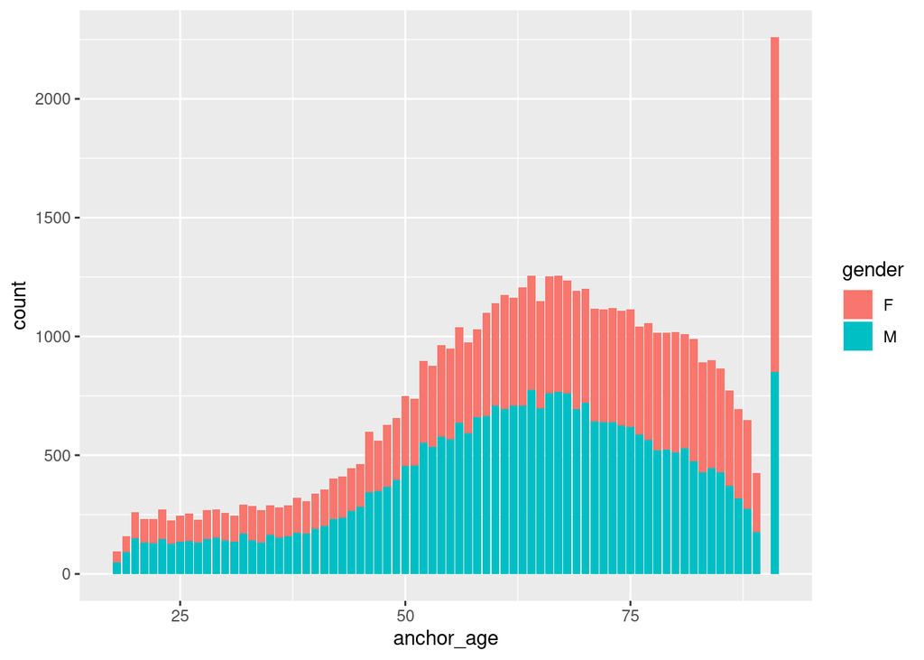

```r
ggplot(data = patients_tble) +
  geom_bar(mapping = aes(x = anchor_age, fill = gender))
```

```r
dum = dummy(patients_tble$gender)
t.test(dum[,2], patients_tble$anchor_age)
```

```
##
##  Welch Two Sample t-test
##
## data:  dum[, 2] and patients_tble$anchor_age
## t = -840.86, df = 53237, p-value < 2.2e-16
## alternative hypothesis: true difference in means is not equal to 0
## 95 percent confidence interval:
##  -63.09961 -62.80613
## sample estimates:
##  mean of x  mean of y
##  0.5606209 63.5134901
```

```r
rm(dum)
gc()
```

```
##           used (Mb) gc trigger  (Mb) max used (Mb)
## Ncells 1411598 75.4    2632487 140.6  2021254  108
## Vcells 4109368 31.4   17421652 133.0 17421652  133
```

## Q5. Lab results

`labevents.csv.gz` (https://mimic.mit.edu/docs/iv/modules/hosp/labevents/) contains all laboratory measurements for patients. The first 10 lines are

```r
system(
  str_c(
    "zcat < ",
    shQuote(str_c(mimic_path, "/hosp/labevents.csv.gz")),
    " | head"
    ),
  intern = TRUE
)
```

```
##  [1] "labevent_id,subject_id,hadm_id,specimen_id,itemid,charttime,storetime,value,valuenum,valueuom,ref_range_lower,ref_range_upper,flag,priority,comments"
##  [2] "670,10000048,,6448755,51484,2126-11-22 19:20:00,2126-11-22 20:07:00,150,150,mg/dL,,,,STAT,"
##  [3] "673,10000048,,6448755,51491,2126-11-22 19:20:00,2126-11-22 20:07:00,6.5,6.5,units,5,8,,STAT,"
##  [4] "675,10000048,,6448755,51498,2126-11-22 19:20:00,2126-11-22 20:07:00,1.029,1.029, ,1.001,1.035,,STAT,"
##  [5] "683,10000048,,82729055,50861,2126-11-22 20:45:00,2126-11-23 00:55:00,39,39,IU/L,0,40,,STAT,"
##  [6] "684,10000048,,82729055,50862,2126-11-22 20:45:00,2126-11-23 00:55:00,4.7,4.7,g/dL,3.4,4.8,,STAT,"
##  [7] "685,10000048,,82729055,50863,2126-11-22 20:45:00,2126-11-23 00:55:00,45,45,IU/L,39,117,,STAT,"
##  [8] "686,10000048,,82729055,50868,2126-11-22 20:45:00,2126-11-22 21:32:00,13,13,mEq/L,8,20,,STAT,"
##  [9] "687,10000048,,82729055,50878,2126-11-22 20:45:00,2126-11-23 00:55:00,28,28,IU/L,0,40,,STAT,"
## [10] "688,10000048,,82729055,50882,2126-11-22 20:45:00,2126-11-22 21:32:00,26,26,mEq/L,22,32,,STAT,"
```

`d_labitems.csv.gz` is the dictionary of lab measurements.

```r
system(
  str_c(
    "zcat < ",
    shQuote(str_c(mimic_path, "/hosp/d_labitems.csv.gz")),
    " | head"
    ),
  intern = TRUE
)
```

```
##  [1] "itemid,label,fluid,category,loinc_code"
##  [2] "51905, ,Other Body Fluid,Chemistry,"
##  [3] "51532,11-Deoxycorticosterone,Blood,Chemistry,"
##  [4] "51957,17-Hydroxycorticosteroids,Urine,Chemistry,"
##  [5] "51958,\"17-Ketosteroids, Urine\",Urine,Chemistry,"
##  [6] "52068,24 Hr,Blood,Hematology,"
##  [7] "51066,24 hr Calcium,Urine,Chemistry,"
##  [8] "51067,24 hr Creatinine,Urine,Chemistry,"
##  [9] "51068,24 hr Protein,Urine,Chemistry,"
## [10] "50853,25-OH Vitamin D,Blood,Chemistry,"
```

1. Find how many rows are in `labevents.csv.gz`.

**Solution**

```bash
gzip -cd "/mnt/mimiciv/1.0/hosp/labevents.csv.gz" | wc -l
```

```
## 122103668
```

2. We are interested in the lab measurements of creatinine (50912), potassium (50971), sodium (50983), chloride (50902), bicarbonate (50882), hematocrit (51221), white blood cell count (51301), glucose (50931), magnesium (50960), and calcium (50893). Retrieve a subset of `labevents.csv.gz` only containing these items for the patients in `icustays_tble` as a tibble `labevents_tble`.

   Hint: `labevents.csv.gz` is a data file too big to be read in by the `read_csv` function in its default setting. Utilize the `col_select` and `lazy` options in the `read_csv` function to reduce the memory burden.

**Solution**

```r
# This is a cycle written by my own for this question, it also works but costs much more time, so I choose to use methods from dplyr.
labevents_tble = read_csv("/mnt/mimiciv/1.0/hosp/labevents_filtered_itemid.csv.gz")
labevents_tble = arrange(labevents_tble, subject_id)
icustays_tble = arrange(icustays_tble, subject_id) %>%
  distinct(subject_id, .keep_all = TRUE)
testtib = labevents_tble[0,]
i = 1
j = 1
while (i <30198827) {
  while (j < 53151) {
    if(icustays_tble[j,1] == labevents_tble[i,1]){
        testtib = add_row(testtib, labevents_tble[i,])
        break
    }else if(icustays_tble[j,1] < labevents_tble[i,1]){
      j = j + 1
    }else{
      break
    }
  }
  i = i + 1
}
labevents_tble = testtib
```

```r
interest_lab_mes = c(50912, 50971, 50983, 50902, 50882, 51221, 51301, 50931, 50960, 50893)
lab_mes = read_csv("/mnt/mimiciv/1.0/hosp/d_labitems.csv.gz", col_select = c(1), show_col_types = FALSE) %>%
  filter(itemid %in% interest_lab_mes)
labevents_tble = read_csv("/mnt/mimiciv/1.0/hosp/labevents_filtered_itemid.csv.gz", show_col_types = FALSE) %>%
  inner_join(select(lab_mes, itemid), by = "itemid") %>%
  inner_join(select(icustays_tble, subject_id), by = "subject_id")
labevents_tble
```

```
## # A tibble: 16,698,462 × 4
##    subject_id itemid charttime           valuenum
##         <dbl>  <dbl> <dttm>                 <dbl>
##  1   10003700  50882 2162-11-15 17:00:00     27
##  2   10003700  50902 2162-11-15 17:00:00    103
##  3   10003700  50912 2162-11-15 17:00:00      1
##  4   10003700  50931 2162-11-15 17:00:00     93
##  5   10003700  50971 2162-11-15 17:00:00      4.1
##  6   10003700  50983 2162-11-15 17:00:00    141
##  7   10003700  51221 2162-11-15 17:00:00     40
##  8   10003700  51301 2162-11-15 17:00:00      6.7
##  9   10003700  51221 2165-04-24 03:40:00     41
## 10   10003700  51301 2165-04-24 03:40:00      5.8
## # … with 16,698,452 more rows
```

```r
rm(lab_mes)
rm(interest_lab_mes)
gc()
```

```
##            used  (Mb) gc trigger   (Mb)  max used   (Mb)
## Ncells  1386763  74.1    2632487  140.6   2264765  121.0
## Vcells 70851573 540.6  266487898 2033.2 321305172 2451.4
```

3. Further restrict `labevents_tble` to the first lab measurement during the ICU stay.

**Solution**

```r
# This is a cycle written by my own for this question, it also works but costs much more time, so I choose to use methods from dplyr.
labevents_tble = read_csv("/mnt/mimiciv/1.0/hosp/labevents_filtered_itemid.csv.gz")
labevents_tble = arrange(labevents_tble, subject_id, charttime) %>%
  distinct(subject_id, .keep_all = TRUE)
icustays_tble = arrange(icustays_tble, subject_id) %>%
  distinct(subject_id, .keep_all = TRUE)
testtib = labevents_tble[0,]
i = 1
j = 1
while (i <273582) {
  while (j < 53151) {
    if(icustays_tble[j,1] == labevents_tble[i,1]){
        testtib = add_row(testtib, labevents_tble[i,])
        break
    }else if(icustays_tble[j,1] < labevents_tble[i,1]){
      j = j + 1
    }else{
      break
    }
  }
  i = i + 1
}
labevents_tble = testtib
labevents_tble
```

```r
labevents_tble = left_join(labevents_tble, select(icustays_tble, subject_id, intime, outtime), by = "subject_id") %>%
  filter(charttime < outtime &
         charttime > intime
         ) %>%
  group_by(subject_id) %>%
  arrange(charttime, .by_group = TRUE) %>%
  slice_head(n = 1) %>%
  ungroup() %>%
  select(-intime, -outtime)
labevents_tble
```

```
## # A tibble: 51,619 × 4
##    subject_id itemid charttime           valuenum
##         <dbl>  <dbl> <dttm>                 <dbl>
##  1   10000032  50882 2180-07-23 21:45:00     21
##  2   10001217  50882 2157-11-21 03:16:00     23
##  3   10001725  50882 2110-04-11 18:02:00     24
##  4   10001884  50882 2131-01-11 06:31:00     33
##  5   10002013  51221 2160-05-18 13:01:00     28.6
##  6   10002155  50882 2129-08-04 17:56:00     25
##  7   10002223  51221 2158-01-15 13:02:00     32.5
##  8   10002348  50882 2112-12-01 06:36:00     23
##  9   10002428  51221 2156-04-12 19:24:00     28.7
## 10   10002430  50882 2129-06-13 00:48:00     22
## # … with 51,609 more rows
```

4. Summarize the lab measurements by appropriate numerics and graphics.

**Solution**

```r
summary(labevents_tble[[4]])# the overall summary statistics of "valuenum".
```

```
##    Min. 1st Qu.  Median    Mean 3rd Qu.    Max.    NA's
##    0.10   22.00   26.70   28.23   33.00  571.00      35
```

```r
labevents_tble %>%
  group_by(itemid) %>%
      summarise(mean(valuenum, na.rm = TRUE))# the mean values of "valuenum" of different "itemid".
```

```
## # A tibble: 10 × 2
##    itemid `mean(valuenum, na.rm = TRUE)`
##     <dbl>                          <dbl>
##  1  50882                          23.3
##  2  50893                           8.05
##  3  50902                         103.
##  4  50912                           1.31
##  5  50931                         212.
##  6  50960                           2.01
##  7  50971                           4.26
##  8  50983                         138.
##  9  51221                          32.3
## 10  51301                          12.6
```

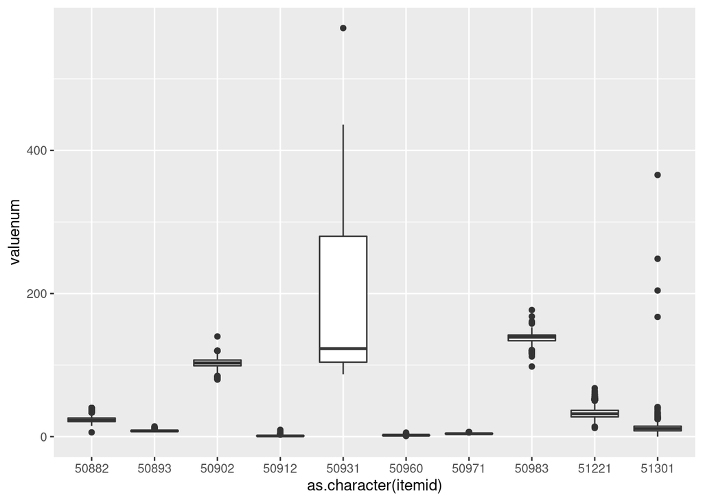

```r
labevents_tble %>%
  ggplot() +
  geom_boxplot(mapping = aes(x = as.character(itemid), y = valuenum)) # the boxplot of "valuenum" of different "itemid".
```

From the boxplot we can see the variation of the item “50931” is significantly large, and other items’ valuenums are fairly stable.

## Q6. Vitals from charted events

`chartevents.csv.gz` (https://mimic.mit.edu/docs/iv/modules/icu/chartevents/) contains all the charted data available for a patient. During their ICU stay, the primary repository of a patient’s information is their electronic chart. The `itemid` variable indicates a single measurement type in the database. The `value` variable is the value measured for `itemid`. The first 10 lines of `chartevents.csv.gz` are

```r
system(
  str_c(
    "zcat < ",
    shQuote(str_c(mimic_path, "/icu/chartevents.csv.gz")),
    " | head"),
  intern = TRUE
)
```

```
##  [1] "subject_id,hadm_id,stay_id,charttime,storetime,itemid,value,valuenum,valueuom,warning"
##  [2] "10003700,28623837,30600691,2165-04-24 05:10:00,2165-04-24 05:11:00,228236,0,0,,0"
##  [3] "10003700,28623837,30600691,2165-04-24 05:12:00,2165-04-24 05:14:00,225067,0,0,,0"
##  [4] "10003700,28623837,30600691,2165-04-24 05:12:00,2165-04-24 05:14:00,225070,1,1,,0"
##  [5] "10003700,28623837,30600691,2165-04-24 05:12:00,2165-04-24 05:14:00,225076,1,1,,0"
##  [6] "10003700,28623837,30600691,2165-04-24 05:12:00,2165-04-24 05:14:00,225078,1,1,,0"
##  [7] "10003700,28623837,30600691,2165-04-24 05:12:00,2165-04-24 05:14:00,225086,1,1,,0"
##  [8] "10003700,28623837,30600691,2165-04-24 05:12:00,2165-04-24 05:14:00,225091,1,1,,0"
##  [9] "10003700,28623837,30600691,2165-04-24 05:12:00,2165-04-24 05:14:00,225103,1,1,,0"
## [10] "10003700,28623837,30600691,2165-04-24 05:12:00,2165-04-24 05:14:00,225106,1,1,,0"
```

`d_items.csv.gz` (https://mimic.mit.edu/docs/iv/modules/icu/d_items/) is the dictionary for the `itemid` in `chartevents.csv.gz`.

```r
system(
  str_c(
    "zcat < ",
    shQuote(str_c(mimic_path, "/icu/d_items.csv.gz")),
    " | head"),
  intern = TRUE
)
```

```
##  [1] "itemid,label,abbreviation,linksto,category,unitname,param_type,lownormalvalue,highnormalvalue"
##  [2] "220003,ICU Admission date,ICU Admission date,datetimeevents,ADT,,Date and time,,"
##  [3] "220045,Heart Rate,HR,chartevents,Routine Vital Signs,bpm,Numeric,,"
##  [4] "220046,Heart rate Alarm - High,HR Alarm - High,chartevents,Alarms,bpm,Numeric,,"
##  [5] "220047,Heart Rate Alarm - Low,HR Alarm - Low,chartevents,Alarms,bpm,Numeric,,"
##  [6] "220048,Heart Rhythm,Heart Rhythm,chartevents,Routine Vital Signs,,Text,,"
##  [7] "220050,Arterial Blood Pressure systolic,ABPs,chartevents,Routine Vital Signs,mmHg,Numeric,90,140"
##  [8] "220051,Arterial Blood Pressure diastolic,ABPd,chartevents,Routine Vital Signs,mmHg,Numeric,60,90"
##  [9] "220052,Arterial Blood Pressure mean,ABPm,chartevents,Routine Vital Signs,mmHg,Numeric,,"
## [10] "220056,Arterial Blood Pressure Alarm - Low,ABP Alarm - Low,chartevents,Alarms,mmHg,Numeric,,"
```

1. We are interested in the vitals for ICU patients: heart rate (220045), mean non-invasive blood pressure (220181), systolic non-invasive blood pressure (220179), body temperature in Fahrenheit (223761), and respiratory rate (220210). Retrieve a subset of `chartevents.csv.gz` only containing these items for the patients in `icustays_tble` as a tibble `chartevents_tble`.

**Solution**

```r
# This is a cycle written by my own for this question, it also works but costs much more time, so I choose to use methods from dplyr.
icustays_tble = read_csv("/mnt/mimiciv/1.0/icu/icustays.csv.gz")
chartevents_tble = read_csv("/mnt/mimiciv/1.0/icu/chartevents_filtered_itemid.csv.gz")
chartevents_tble = arrange(chartevents_tble, subject_id, hadm_id)
icustays_tble = arrange(icustays_tble, subject_id, hadm_id, intime)
testtib = chartevents_tble[0,]
i = 1
j = 1
while (i < 23679058) {
  while (j < 76541) {
    if(icustays_tble[j,1] == chartevents_tble[i,1]){
      if(icustays_tble[j,2] == chartevents_tble[i,2]){
        testtib = add_row(testtib, chartevents_tble[i,])
        break
      }else if(icustays_tble[j,2] < chartevents_tble[i,2]){
        j = j + 1
      }else {
        break
      }
    }else if(icustays_tble[j,1] < chartevents_tble[i,1]){
      j = j + 1
    }else{
      break
    }
  }
  i = i + 1
}
chartevents_tble = testtib
```

```r
interest_vit = c(220045, 220181, 220179, 223761, 220210)
vit = read_csv( "/mnt/mimiciv/1.0/icu/d_items.csv.gz", col_select = c(1), show_col_types = FALSE) %>%
  filter(itemid %in% interest_vit)
chartevents_tble = read_csv("/mnt/mimiciv/1.0/icu/chartevents_filtered_itemid.csv.gz", show_col_types = FALSE) %>%
  inner_join(select(vit, itemid), by = "itemid") %>%
  inner_join(select(icustays_tble, subject_id), by = "subject_id")
chartevents_tble
```

```
## # A tibble: 23,679,058 × 6
##    subject_id  hadm_id  stay_id charttime           itemid valuenum
##         <dbl>    <dbl>    <dbl> <dttm>               <dbl>    <dbl>
##  1   10003700 28623837 30600691 2165-04-24 05:28:00 220179    152
##  2   10003700 28623837 30600691 2165-04-24 05:28:00 220181    110
##  3   10003700 28623837 30600691 2165-04-24 05:30:00 220045     65
##  4   10003700 28623837 30600691 2165-04-24 05:30:00 220210     14
##  5   10003700 28623837 30600691 2165-04-24 05:38:00 223761     97.6
##  6   10003700 28623837 30600691 2165-04-24 06:00:00 220045     56
##  7   10003700 28623837 30600691 2165-04-24 06:00:00 220179    126
##  8   10003700 28623837 30600691 2165-04-24 06:00:00 220181     88
##  9   10003700 28623837 30600691 2165-04-24 06:00:00 220210     14
## 10   10003700 28623837 30600691 2165-04-24 06:09:00 220045     55
## # … with 23,679,048 more rows
```

```r
rm(vit)
rm(interest_vit)
gc()
```

```
##             used   (Mb) gc trigger   (Mb)  max used   (Mb)
## Ncells   1412295   75.5    2632487  140.6   2632487  140.6
## Vcells 146372245 1116.8  383918572 2929.1 321305172 2451.4
```

2. Further restrict `chartevents_tble` to the first vital measurement during the ICU stay.

**Solution**

```r
# This is a cycle written by my own for this question, it also works but costs much more time, so I choose to use methods from dplyr.
icustays_tble = read_csv("/mnt/mimiciv/1.0/icu/icustays.csv.gz")
chartevents_tble = read_csv("/mnt/mimiciv/1.0/icu/chartevents_filtered_itemid.csv.gz")
chartevents_tble = arrange(chartevents_tble, subject_id, charttime) %>%
  distinct(subject_id, .keep_all = TRUE) #RMK, here I add "charttime" into the function "arrange()" in order to select the first vital measurement during the ICU stay for each patient

icustays_tble = arrange(icustays_tble, subject_id, hadm_id, intime)

testtib = chartevents_tble[0,]
i = 1
j = 1
while (i < 53151) {
  while (j < 76541) {
    if(icustays_tble[j,1] == chartevents_tble[i,1]){
      if(icustays_tble[j,2] == chartevents_tble[i,2]){
        testtib = rbind(testtib, chartevents_tble[i,])
        break
      }else if(icustays_tble[j,2] < chartevents_tble[i,2]){
        j = j + 1
      }else {
        break
      }
    }else if(icustays_tble[j,1] < chartevents_tble[i,1]){
      j = j + 1
    }else{
      break
    }
  }
  i = i + 1
}
chartevents_tble = testtib
chartevents_tble
```

```r
chartevents_tble = left_join(chartevents_tble, select(icustays_tble, subject_id, intime, outtime), by = "subject_id") %>%
  filter(charttime < outtime &
         charttime > intime
         ) %>%
  group_by(subject_id) %>%
  arrange(charttime, .by_group = TRUE) %>%
  slice_head(n = 1) %>%
  ungroup() %>%
  select(-intime, -outtime)
chartevents_tble
```

```
## # A tibble: 53,136 × 6
##    subject_id  hadm_id  stay_id charttime           itemid valuenum
##         <dbl>    <dbl>    <dbl> <dttm>               <dbl>    <dbl>
##  1   10000032 29079034 39553978 2180-07-23 14:11:00 220179     84
##  2   10000980 26913865 39765666 2189-06-27 08:54:00 220210     23
##  3   10001217 24597018 37067082 2157-11-20 19:19:00 220045     86
##  4   10001725 25563031 31205490 2110-04-11 15:54:00 220045     55
##  5   10001884 26184834 37510196 2131-01-11 04:22:00 220045     38
##  6   10002013 23581541 39060235 2160-05-18 14:07:00 220045     80
##  7   10002155 23822395 33685454 2129-08-04 13:45:00 220045     68
##  8   10002223 22494570 39638202 2158-01-15 08:15:00 220045    100
##  9   10002348 22725460 32610785 2112-11-30 23:31:00 223761     97.9
## 10   10002428 28662225 33987268 2156-04-12 17:25:00 223761    103.
## # … with 53,126 more rows
```

3. Summarize these vital measurements by appropriate numerics and graphics.

**Solution**

```r
summary(chartevents_tble[[6]])# the overall "valuenum"
```

```
##    Min. 1st Qu.  Median    Mean 3rd Qu.    Max.
##     0.0    75.0    90.0    90.2   103.0   941.0
```

```r
chartevents_tble %>%
  group_by(itemid) %>%
      summarise(mean(valuenum, na.rm = TRUE))# the mean values of "valuenum" of different "itemid".
```

```
## # A tibble: 5 × 2
##   itemid `mean(valuenum, na.rm = TRUE)`
##    <dbl>                          <dbl>
## 1 220045                           87.2
## 2 220179                          127.
## 3 220181                           93.4
## 4 220210                           19.7
## 5 223761                           98.1
```

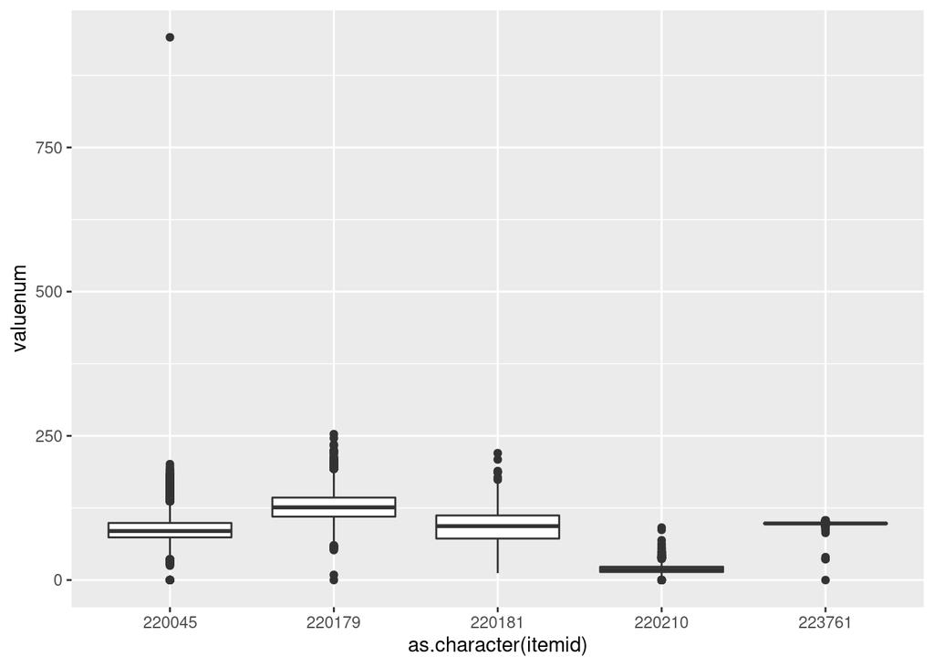

```r
chartevents_tble %>%
  ggplot() +
  geom_boxplot(mapping = aes(x = as.character(itemid), y = valuenum)) # the boxplot of "valuenum" of different "itemid".
```

## Q7. Putting things together

Let us create a tibble `mimic_icu_cohort` for all ICU stays, where rows are

- first ICU stay of each unique adult (age at admission > 18)

and columns contain at least following variables

- all variables in `icustays.csv.gz`
- all variables in `admission.csv.gz`
- all variables in `patients.csv.gz`
- first lab measurements during ICU stay
- first vital measurements during ICU stay
- an indicator variable `thirty_day_mort` whether the patient died within 30 days of hospital admission (30 day mortality)

**Solution**

```r
mimic_icu_cohort = left_join(icustays_tble, admissions_tble, by = "subject_id") %>%
  left_join(patients_tble, by = "subject_id") %>%
  left_join(labevents_tble, by = "subject_id") %>%
  left_join(chartevents_tble, by = "subject_id")

mimic_icu_cohort$thirty_day_mort_time = mimic_icu_cohort[, 12] - mimic_icu_cohort[, 10]
i = 1
while (i < 53151) {
  mimic_icu_cohort[i, 37] = as.character(mimic_icu_cohort[i, 36])
  i = i + 1
}

i = 1
mimic_icu_cohort$thirty_day_mort = "0"
while (i < 53151) {
  if(str_length(mimic_icu_cohort[i,37]) != 20){
    if(str_length(mimic_icu_cohort[i,37]) < 23){
      mimic_icu_cohort[i, 38] = "1"
      i = i + 1
    }else if(str_length(mimic_icu_cohort[i,37]) > 23){
       mimic_icu_cohort[i, 38] = "0"
       i = i + 1
    }else{
      dtime = mimic_icu_cohort[i,37] %>%
      substring(18, 22) %>%
      as.numeric()
        if(dtime < 43201){
        mimic_icu_cohort[i, 38] = "1"
        i = i + 1
        }else{
        mimic_icu_cohort[i, 38] = "0"
        i = i + 1
        }
    }
  }else if(substr(mimic_icu_cohort[2,37], 18, 19) == "NA"){
    mimic_icu_cohort[i, 38] = "0"
    i = i + 1
  }else{
     mimic_icu_cohort[i, 38] = "1"
    i = i + 1
  }
}
#mimic_icu_cohort$thirty_day_mort = mimic_icu_cohort[38]
mimic_icu_cohort = mimic_icu_cohort[-c(36:37)] #delete all intermediate columns that used to obtain column "thirty_day_mort".
mimic_icu_cohort %>%
  print(n = 10, width = Inf)
```

```
## # A tibble: 53,150 × 36
##    subject_id hadm_id.x stay_id.x
##         <dbl>     <dbl>     <dbl>
##  1   10000032  29079034  39553978
##  2   10000980  26913865  39765666
##  3   10001217  24597018  37067082
##  4   10001725  25563031  31205490
##  5   10001884  26184834  37510196
##  6   10002013  23581541  39060235
##  7   10002155  23822395  33685454
##  8   10002223  22494570  39638202
##  9   10002348  22725460  32610785
## 10   10002428  28662225  33987268
##    first_careunit
##    <chr>
```

[output cut: 107 more lines]

## Q8. Exploratory data analysis (EDA)

Summarize following information using appropriate numerics or graphs.

**Solution**

- `thirty_day_mort` vs demographic variables (ethnicity, language, insurance, marital_status, gender, age at hospital admission)

`thirty_day_mort` vs `ethnicity`

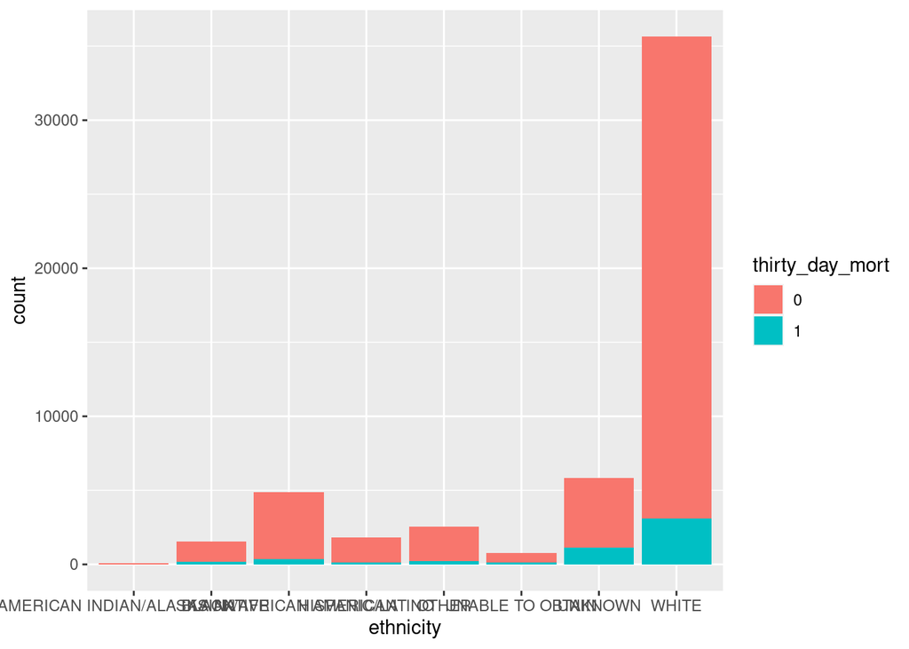

```r
ggplot(data = mimic_icu_cohort) +
  geom_bar(mapping = aes(x = ethnicity, fill = thirty_day_mort))
```

`thirty_day_mort` vs `language`

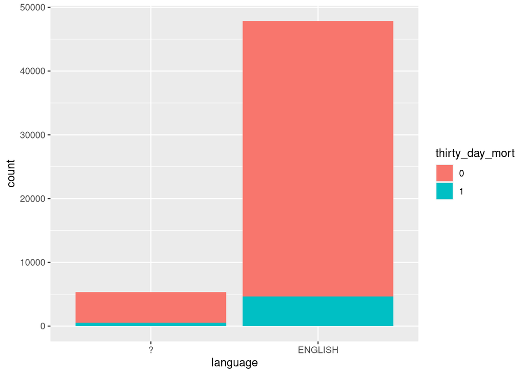

```r
ggplot(data = mimic_icu_cohort) +
  geom_bar(mapping = aes(x = language, fill = thirty_day_mort))
```

`thirty_day_mort` vs `insurance`

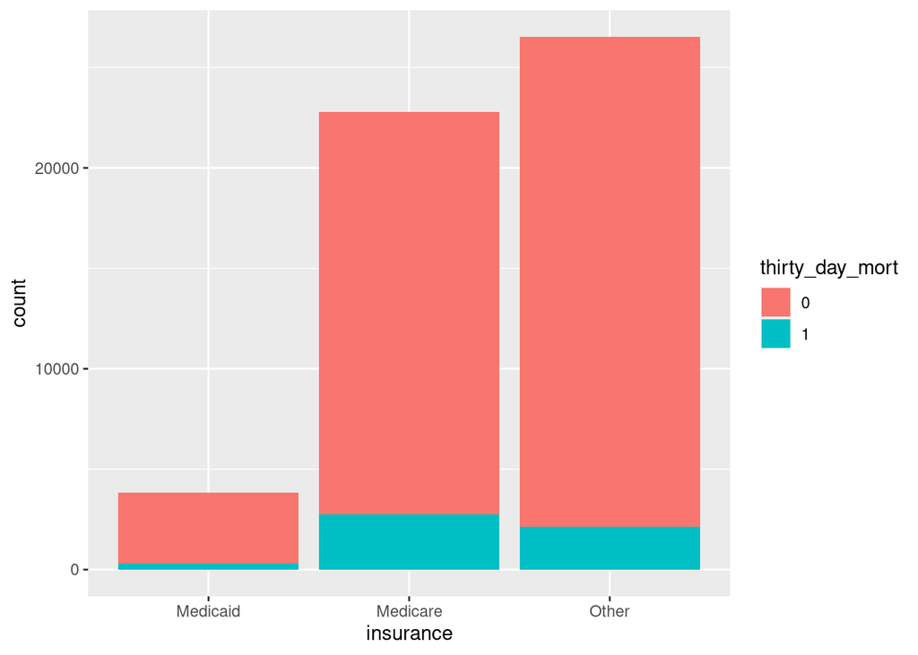

```r
ggplot(data = mimic_icu_cohort) +
  geom_bar(mapping = aes(x = insurance, fill = thirty_day_mort))
```

`thirty_day_mort` vs `marital_status`

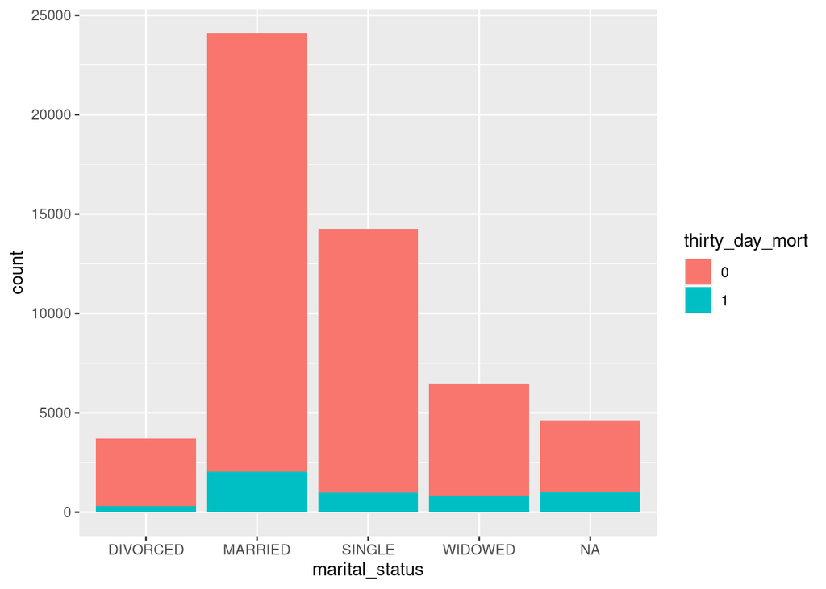

```r
ggplot(data = mimic_icu_cohort) +
  geom_bar(mapping = aes(x = marital_status, fill = thirty_day_mort))
```

`thirty_day_mort` vs `gender`

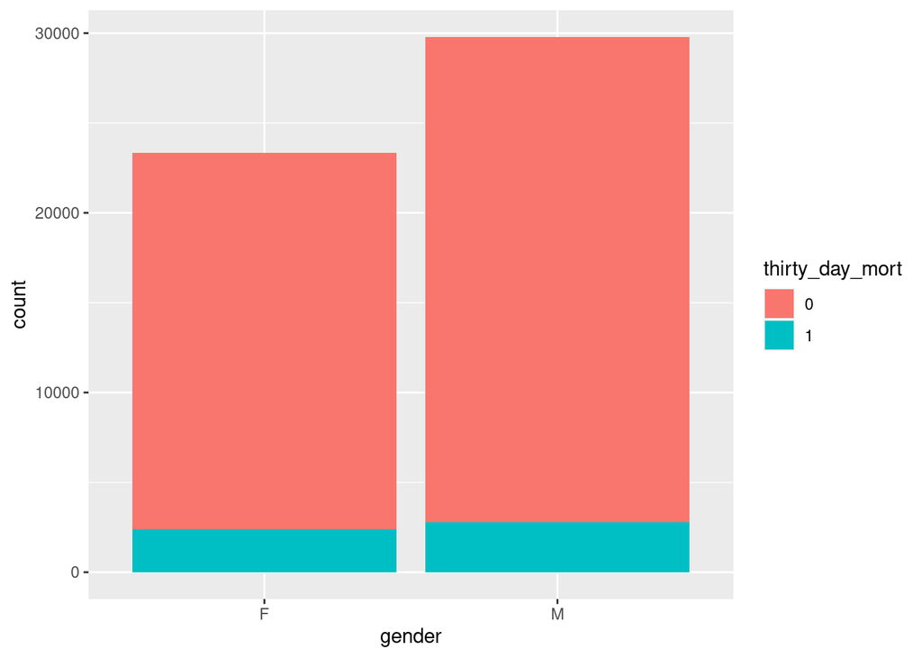

```r
ggplot(data = mimic_icu_cohort) +
  geom_bar(mapping = aes(x = gender, fill = thirty_day_mort))
```

`thirty_day_mort` vs `age at hospital admission`

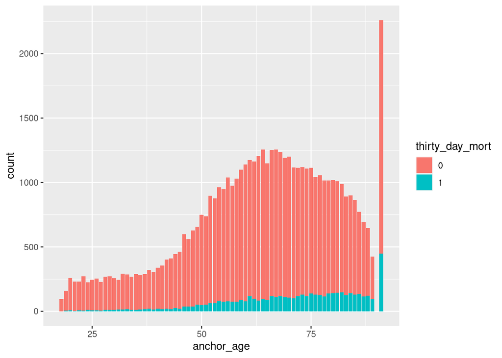

```r
ggplot(data = mimic_icu_cohort) +
  geom_bar(mapping = aes(x = anchor_age, fill = thirty_day_mort))
```

- `thirty_day_mort` vs first lab measurements

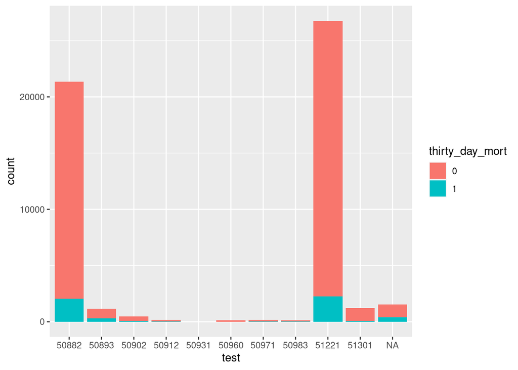

```r
mimic_icu_cohort$test = mimic_icu_cohort$itemid.x #here since the orginal column type of "itemid.x" is numeric, there will be much blank in x-axis, so I create a new variable "test" to convert the column type to factor.
mimic_icu_cohort$test = as.factor(mimic_icu_cohort$test)
ggplot(data = mimic_icu_cohort) +
  geom_bar(mapping = aes(x = test, fill = thirty_day_mort))
```

```r
mimic_icu_cohort = mimic_icu_cohort[-37]
```

- `thirty_day_mort` vs first vital measurements

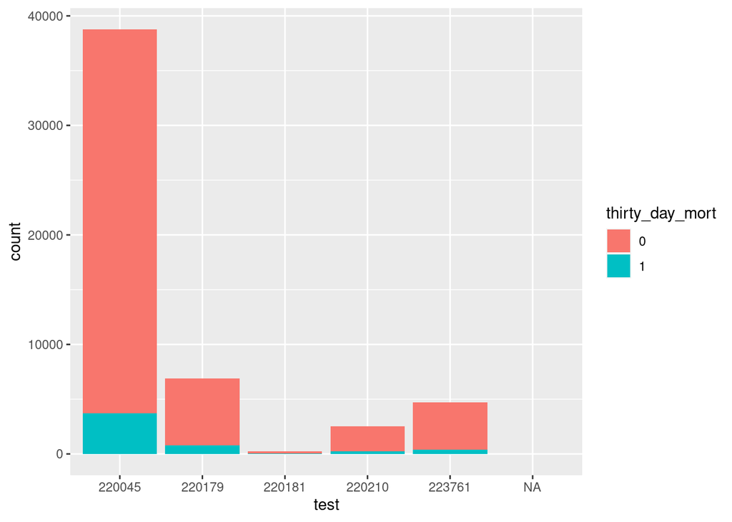

```r
mimic_icu_cohort$test = mimic_icu_cohort$itemid.y #Similar as above.
mimic_icu_cohort$test = as.factor(mimic_icu_cohort$test)
ggplot(data = mimic_icu_cohort) +
  geom_bar(mapping = aes(x = test, fill = thirty_day_mort))
```

```r
mimic_icu_cohort = mimic_icu_cohort[-37]
```

- `thirty_day_mort` vs first ICU unit

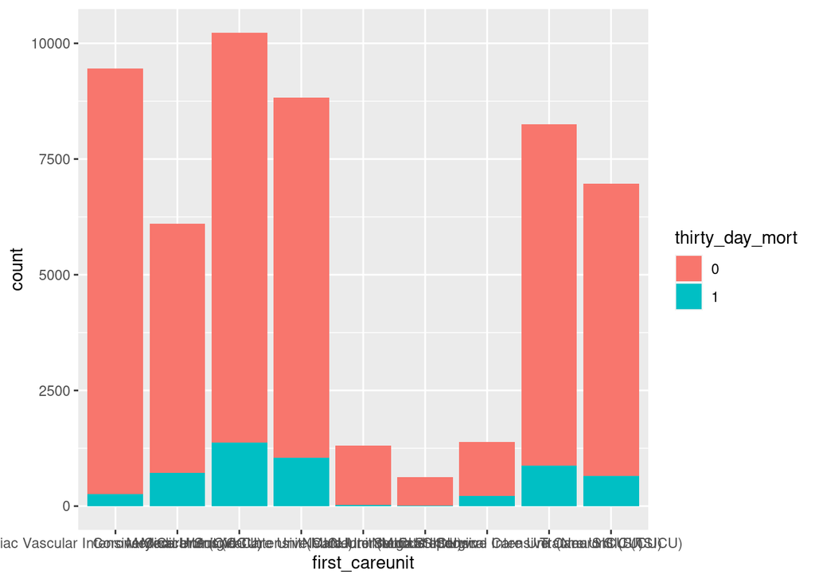

```r
ggplot(data = mimic_icu_cohort) +
  geom_bar(mapping = aes(x = first_careunit, fill = thirty_day_mort))
```